# 2016 Presidential Campaign Contributions in Michigan

## by Liz Kalina

This report explores a dataset containing campaign contributions to all candidates in the 2016 presidential election by Michigan residents. As a former Michigander, I’m particularly interested in Michigan’s current political climate.

## Univariate Plots Section

#### Dataset Characteristics

```
## 'data.frame':    163765 obs. of  18 variables:
##  $ cmte_id          : chr  "C00580100" "C00580100" "C00580100" "C00580100" ...
##  $ cand_id          : chr  "P80001571" "P80001571" "P80001571" "P80001571" ...
##  $ cand_nm          : chr  "Trump, Donald J." "Trump, Donald J." "Trump, Donald J." "Trump, Donald J." ...
##  $ contbr_nm        : chr  "RODDEN, JULIE" "SELLERS, KENNETH" "SELLERS, KENNETH" "SELLERS, KENNETH" ...
##  $ contbr_city      : chr  "TAYLOR" "BROWNSTOWN" "BROWNSTOWN" "BROWNSTOWN" ...
##  $ contbr_st        : chr  "MI" "MI" "MI" "MI" ...
##  $ contbr_zip       : int  48180 48134 48134 48134 48134 493029352 48067 48382 490096510 498539211 ...
##  $ contbr_employer  : chr  "INFORMATION REQUESTED" "DOD" "DOD" "DOD" ...
##  $ contbr_occupation: chr  "INFORMATION REQUESTED" "QA SPECILAIST" "QA SPECILAIST" "QA SPECILAIST" ...
##  $ contb_receipt_amt: num  76.4 -20 -20 -20 -20 ...
##  $ contb_receipt_dt : chr  "09-NOV-16" "06-OCT-16" "13-OCT-16" "20-OCT-16" ...
##  $ receipt_desc     : chr  "" "" "" "" ...
##  $ memo_cd          : chr  "X" "X" "X" "X" ...
##  $ memo_text        : chr  "" "" "" "" ...
##  $ form_tp          : chr  "SA18" "SA18" "SA18" "SA18" ...
##  $ file_num         : int  1146165 1146165 1146165 1146165 1146165 1091718 1146165 1146165 1077404 1091718 ...
##  $ tran_id          : chr  "SA18.133973" "SA18.188012" "SA18.188013" "SA18.188014" ...
##  $ election_tp      : chr  "G2016" "G2016" "G2016" "G2016" ...
```

#### Unique Candidate Count

```
## [1] 24
```

Our dataset consists of 18 variables, with 163,765 observations and 24 individual candidates that residents contributed to.

#### Summary of Contributions to Each Candidates

```
## # A tibble: 24 × 5
##                      cand_nm total        avg  median   max
##                        <chr> <int>      <dbl>   <dbl> <dbl>
## 1    Clinton, Hillary Rodham 68774   94.91927   25.00  5400
## 2           Sanders, Bernard 47889   41.69198   27.00  2700
## 3           Trump, Donald J. 20934  140.83903   55.13  5000
## 4  Cruz, Rafael Edward 'Ted' 11306   81.30434   50.00 10800
## 5        Carson, Benjamin S.  9075  106.11952   50.00  5400
## 6               Rubio, Marco  1726  420.28802  100.00  5400
## 7                 Paul, Rand  1012  197.83497   50.00  2700
## 8            Kasich, John R.   779  539.46098  200.00  2700
## 9                  Bush, Jeb   768 1258.82096 1000.00  5400
## 10            Fiorina, Carly   551  188.77677  100.00  2700
## # ... with 14 more rows
```

The top Democratic candidates (Hillary Clinton, Bernie Sanders) received the largest number of donations, while the top three Republican candidates (Donald Trump, Ted Cruz, Ben Carson) received fewer overall donations. The median donation per Republican candidate was roughly double that of the Democrats.

#### Summary of Contributions by City

```
## # A tibble: 1,238 × 5
##         contbr_city total       avg median   max
##               <chr> <int>     <dbl>  <dbl> <dbl>
## 1         ANN ARBOR 13962 102.66451  30.00  2700
## 2      GRAND RAPIDS  6616 112.36365  27.00  5400
## 3           DETROIT  4260 115.50208  27.00  5400
## 4         KALAMAZOO  3355  79.05810  33.55  2700
## 5           LANSING  3137  61.98019  25.00  2700
## 6         ROYAL OAK  2861  79.54320  25.00  2700
## 7      EAST LANSING  2631  88.04159  30.00  5400
## 8  BLOOMFIELD HILLS  2615 320.46039  80.00  5400
## 9  FARMINGTON HILLS  2289 131.50433  25.00 10800
## 10        YPSILANTI  2286  64.85254  27.00  2700
## # ... with 1,228 more rows
```

The five cities with the largest number of donations were Ann Arbor, Grand Rapids, Detroit, Kalamazoo and Lansing. Some cities, such as Bloomfield Hills and Grosse Pointe, had much larger median donations, which aligns with my understanding of the wealth in these communities.

### Contribution Histograms

#### Overall Distribution

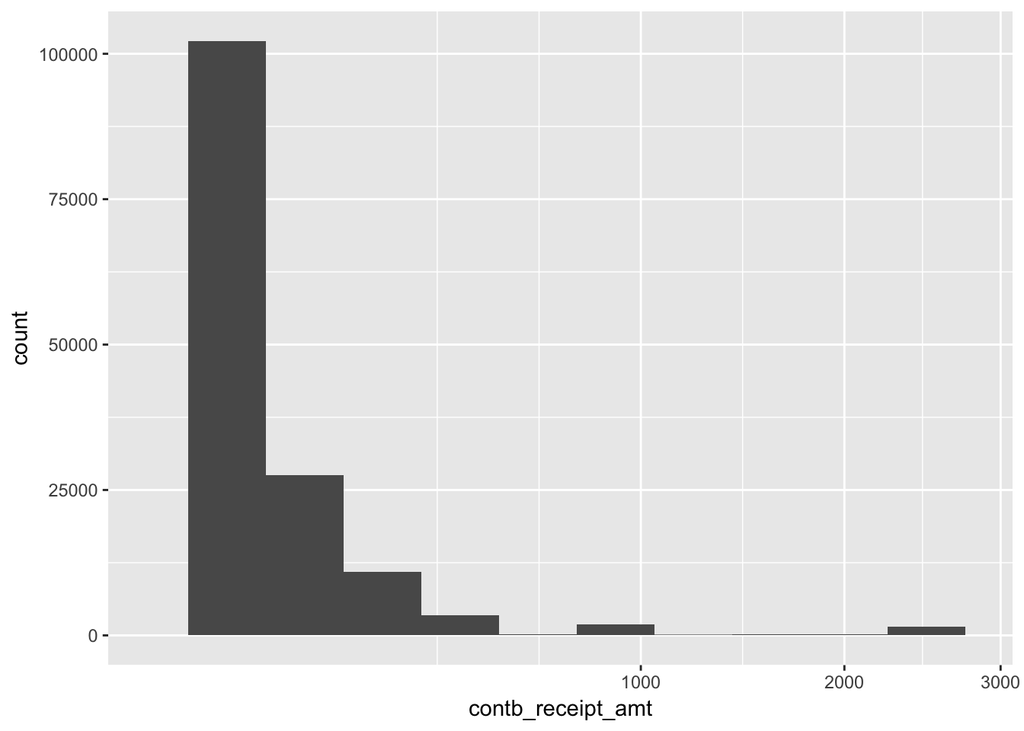

A vast majority of donations were less than $500, which shows that it’s not just rich donors making a majority of the contributions at least in the context of individual donations.

#### Contributions less than $100

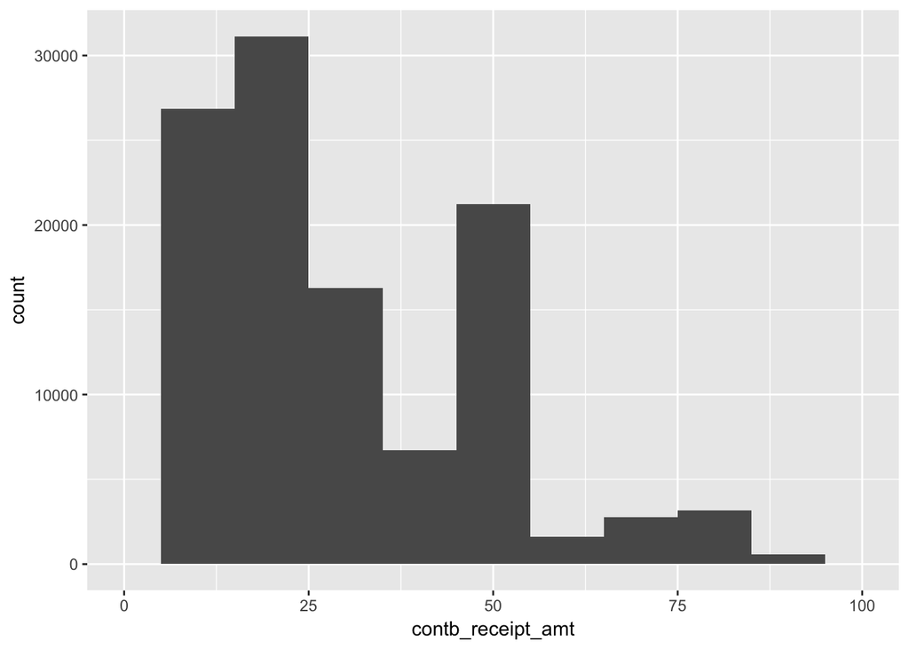

For donations less than $100, you can notice peaks around $25, $50 and $75 which aligns with suggested donation amounts incremented by $25.

#### Contributions less than $400

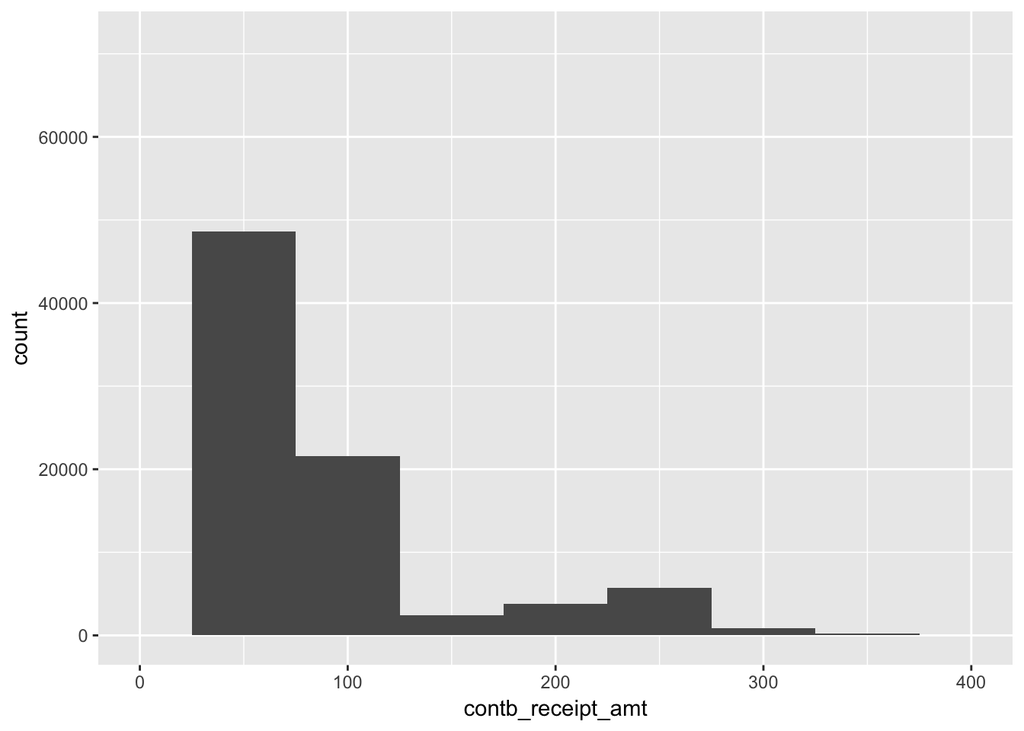

#### Contributions greater than $1000

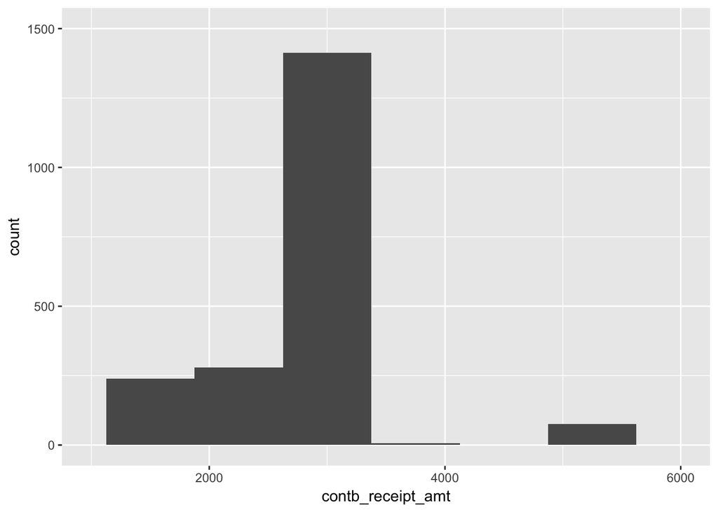

According to the Federal Election Commission, individual contribution limits are:

> $2,700 per election to a Federal candidate or the candidate’s campaign committee. Notice that the limit applies separately to each election. Primaries, runoffs and general elections are considered separate elections.

Since presidential campaigns have primaries and general elections, you can see this reflected in the clustering of contribution counts at $2700 and $5400.

### Candidates with the Most and Fewest Donations

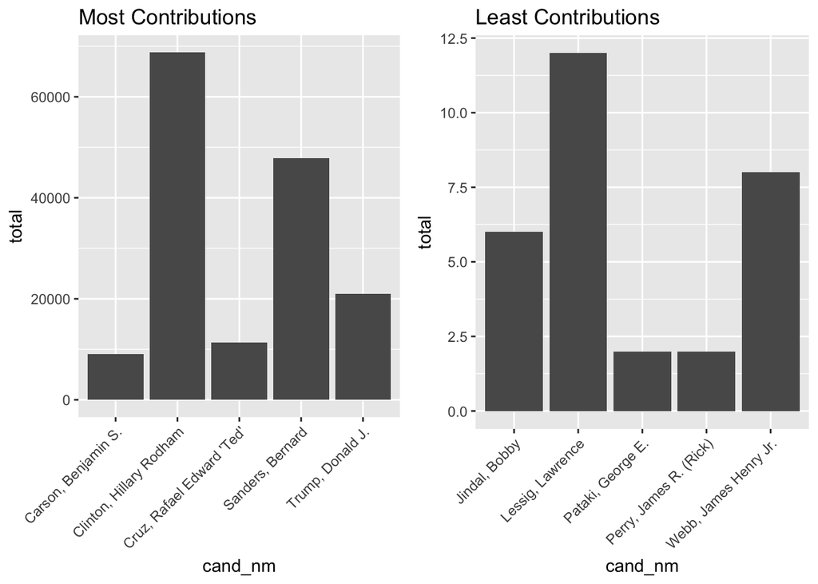

### Contributor Occupations and Employers

#### By Employer

```
## # A tibble: 10,583 × 2
##              contbr_employer total
##                        <chr> <int>
## 1                    RETIRED 25141
## 2                        N/A 24051
## 3                       NONE 11788
## 4              SELF-EMPLOYED  8505
## 5      INFORMATION REQUESTED  6644
## 6               NOT EMPLOYED  6276
## 7     UNIVERSITY OF MICHIGAN  3824
## 8              SELF EMPLOYED  3504
## 9                       SELF  2555
## 10 MICHIGAN STATE UNIVERSITY  1604
## # ... with 10,573 more rows
```

#### By Occupation

```
## # A tibble: 5,748 × 2
##        contbr_occupation total
##                    <chr> <int>
## 1                RETIRED 43876
## 2           NOT EMPLOYED 15306
## 3  INFORMATION REQUESTED  6675
## 4              PROFESSOR  3540
## 5               ATTORNEY  3032
## 6                TEACHER  2838
## 7              HOMEMAKER  2643
## 8              PHYSICIAN  2630
## 9               ENGINEER  2592
## 10                 SALES  1370
## # ... with 5,738 more rows
```

Employment Observations

- Retired people are the most frequent contibutors by far
- Employees of universities, automakers and hosptial systems are frequent contributors
- There are a large number of contributions without employer and occupation info

### Contribution Timing

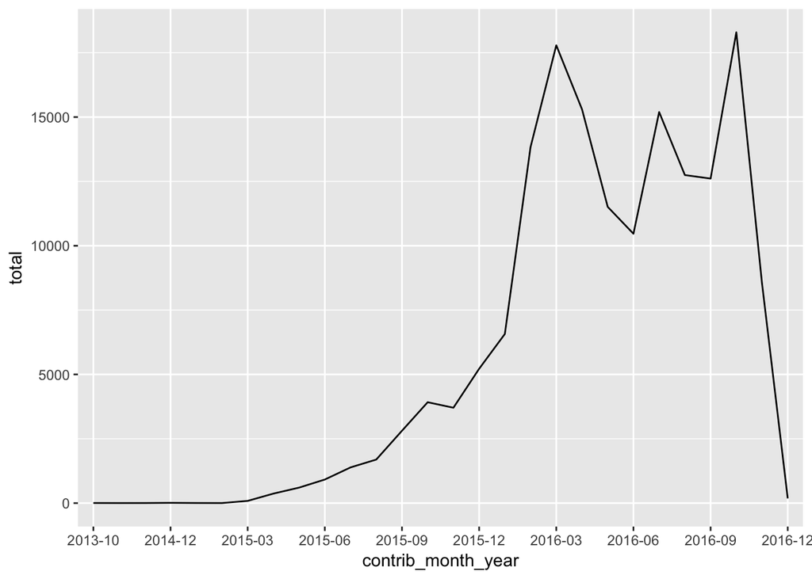

From the plot above, you can see a gradual climb in donations during 2015 and a steep climb from January to March 2016. There are three contribution peaks in 2016 — in March, July and October — each coinciding with an election event. There was the Michigan Primary on March 8th, the Democratic and Republican national conventions at the end of July and the general election on November 8th.

## Univariate Summary

To me, the most interesting features in this dataset are ‘cand_nm’, ‘contbr_nm’, ‘contbr_zip’, ‘contb_receipt_amt’ and ‘contb_receipt_dt.’ I can use ‘contb_receipt_amt’ and ‘contb_receipt_dt’ for each contribution to investigate temporal and candidate popularity trends. With ‘contbr_nm’ and ‘contbr_zip’, I can infer information about the contributor such as geographic location and gender.

A few takeaways from my analysis so far are that Democratic candidates received more contributions than Republicans and that a majority of contributions are small (less than $500). Other interesting things I noticed were that contribution amounts cluster around campaign maxs for larger donors and contributions peak around key election events (like primaries, conventions or scandals).

# Bivariate Plots Section

#### Add Gender to Contributors

In order to determine each contributors gender, I used the ‘gender’ package in R, which encodes gender based on names and dates of birth using historical datasets. I decided to use a threshold of 75% certainty to assign a gender to a contributor.

### Political Party Investigation

#### Contributor Gender vs. Candidate Political Party

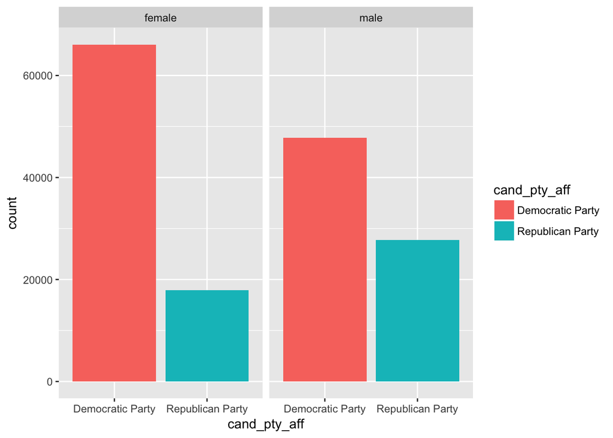

Both men and women in Michigan donate more to Democrats than Republicans; however, women are significantly more likely to donate Democratic than men.

#### Contributions Counts by Date and Political Party

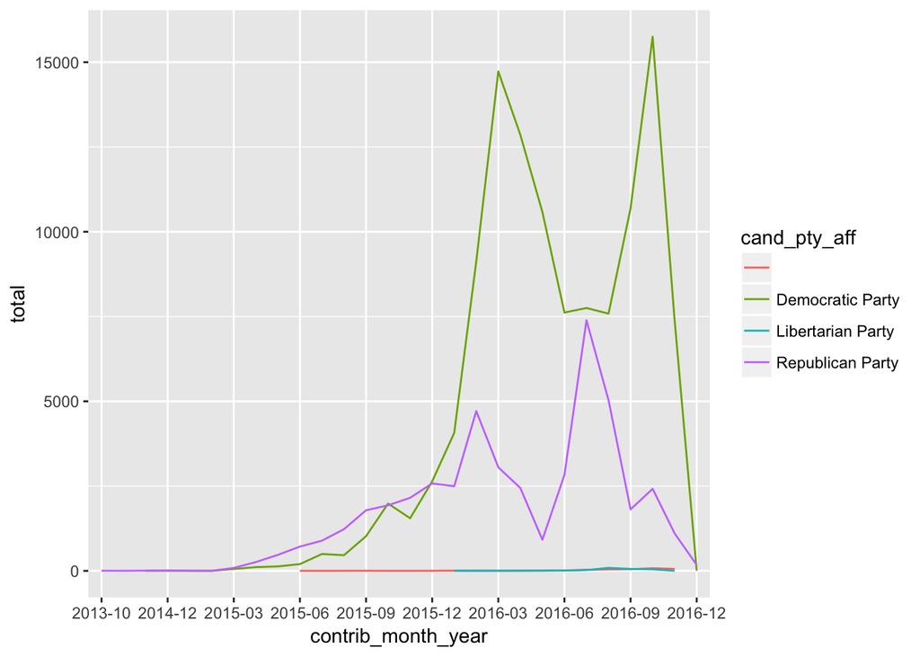

While Republicans actually donated more prior to 2016, the Democratic candidates received the overall majority of contributions. There were very few donations that were Libertarian or not marked for a particular party.

#### Republican Candidate Contribution Counts by Date

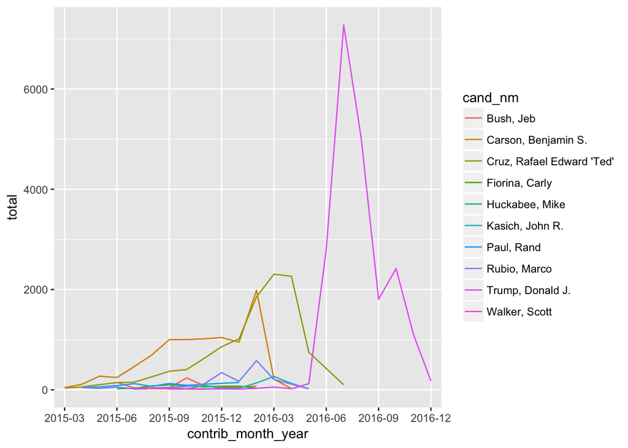

I think this plot is really interesting because it shows that Trump had almost no financial contributions prior to the Republican Primary on March 8, 2016. The leaders before the primary were Ben Carson and Ted Cruz. Trump’s support peaked at the Republican National Convention at the end of July and then steadily declined until the month before the general election when it had a small resurgence.

## Bivariate Summary

# Multivariate Plots Section

#### Hillary vs. Trump over Time

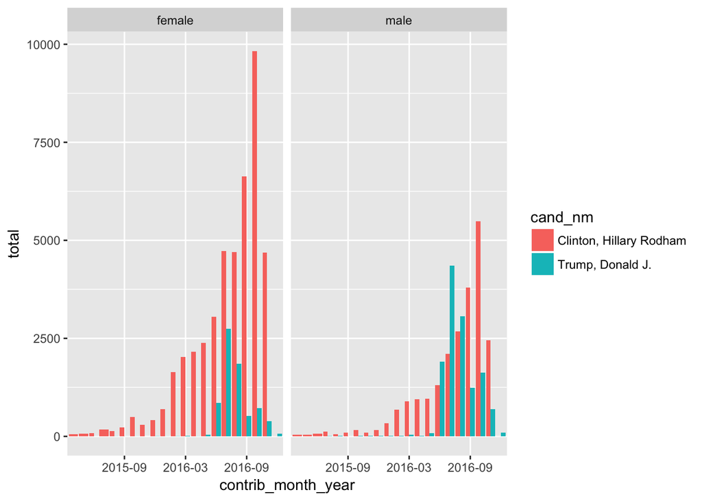

Donation trends to Hillary vs. Trump were uniform in shape, but not in scale across the genders and time. One key difference is that women always donated more to Hillary than Trump, while men donated more to different candidates at different points in time. In the months right before the general election, men actually made more donations to Hillary!

### Contribution Amount Distribution

#### Top 5 Candidates

[figure not shown]

#### By Political Party and Gender

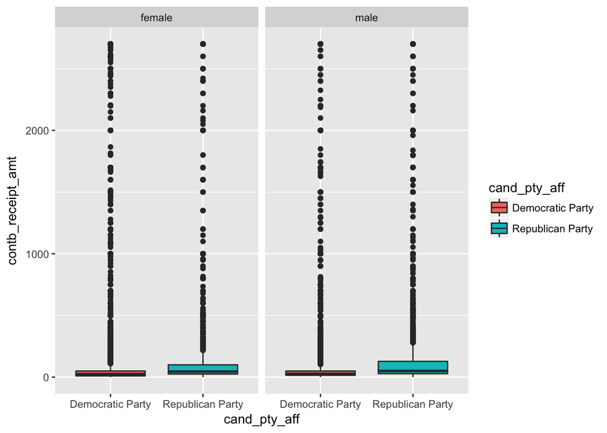

From this boxplot, you can see that the interquartile range for contribution amounts is less than $100 across gender/political party and that Republican men give the most per contribution.

### Determine Population Density and Unemployment Rate of Contributor Zip Codes

These two datasets were available on the Splitwise blog as downloads. According to the author, this data came from:

> Two different Census APIs (the Decennial Census 2010 and the ACS 5-year 2007-2011), combined with the square-footage by ZCTA listings from the 2013 U.S. Gazetteer Files.

I believe that understanding the community type and economic prospects will be a strong indicator of candidate preference.

### Classify Contributor Community Type based on Population Density

Classification (People per Square Mile):

- rural: < 102
- suburban: 103 to 2,213
- urban: > 2213

These cutoffs are based on an analysis presented on the FiveThirtyEight blog:

> Our analysis showed that the single best predictor of whether someone said his or her area was urban, suburban or rural was ZIP code density. Residents of ZIP codes with more than 2,213 people per square mile typically described their area as urban. Residents of neighborhoods with 102 to 2,213 people per square mile typically called their area suburban. In ZIP codes with fewer than 102 people per square mile, residents typically said they lived in a rural area.

#### Party Affiliation vs. Unemployment vs. Population Density

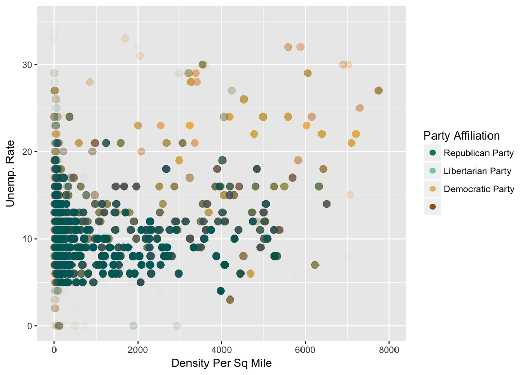

In general, Democratic contributors appear to live in areas with higher population density and higher unemployment while Republicans seem to live in areas with average unemployment and lower to moderate population density.

#### Correlation: Population Density, Gender, Party Affiliation

```
##                               Density Per Sq Mile gender.male
## Density Per Sq Mile                             1
## gender.male                                  0.01           1
## gender.female                               -0.02       -0.95
## cand_pty_aff.Democratic Party                0.16       -0.17
## cand_pty_aff.Republican Party               -0.16        0.17
##                               gender.female cand_pty_aff.Democratic Party
## Density Per Sq Mile
## gender.male
## gender.female                             1
## cand_pty_aff.Democratic Party          0.16                             1
## cand_pty_aff.Republican Party         -0.16                         -0.99
##                               cand_pty_aff.Republican Party
## Density Per Sq Mile
## gender.male
## gender.female
## cand_pty_aff.Democratic Party
## cand_pty_aff.Republican Party                             1
```

Correlation Observations

- There are minor correlations between:
- Democrats: higher population density, female
- Republicans: lower population density, male

#### Donation Amounts vs. Zip Code

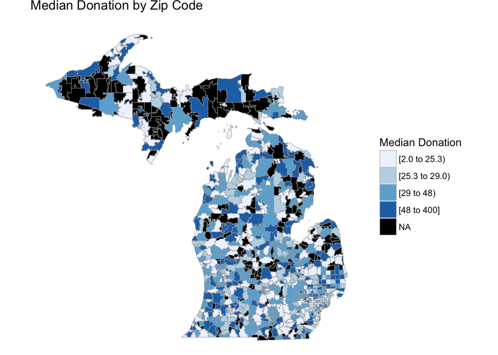

The geography of median donation seems to be relatively evenly distributed across the state with the exeception of Metro Detroit which is almost uniformly less than $30. The black regions are excluded zip codes since they have less than 10 donations.

#### Correlation: Median Donation, Total Donations, Party Leaning

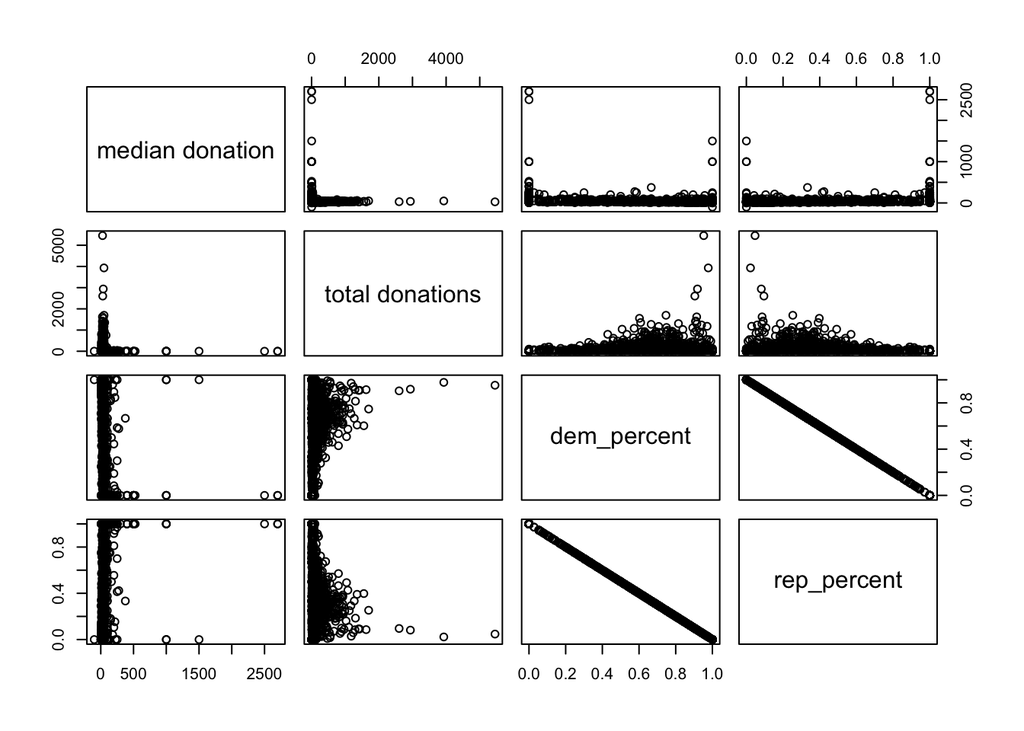

The above scatterplot matrix shows each zip code as a point. This plot simply reinforces that Democrats live in more densely populated areas than Republicans, since the Democratic zip code have more total donations than the Republican zips.

## Multivariate Summary

In this section, I investigated support for Hillary vs. Trump over time, the size of campaign contributions for Democrats vs. Republicans as well as the relationship between population density and unemployment to party affiliation. I observed that Democratic indicators include high population density and female gender, while Republican indicators are low population density and male gender. Other observations include that Republicans (particularly Republican men) give larger donations and although men favored Trump to Hillary, men actually made more contributions to Hillary in the last few months leading up to the general election.

# Final Plots and Summary

## Plot One

### Hillary vs. Bernie

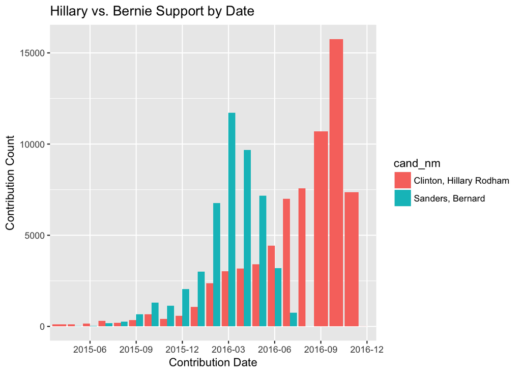

### Description One

The above plot shows that Bernie Sanders actually had more support (based on number of contributions) from 2015 to well after the Democratic Primary. It was not until June 2016 that Hillary surpassed Bernie in number of donations, and not until after the DNC that Bernie support fully dried up. This coincides with my understanding of Bernie as a grassroots candidate with widespread and loyal supporters.

## Plot Two

### Party Leanings based on Zip Code

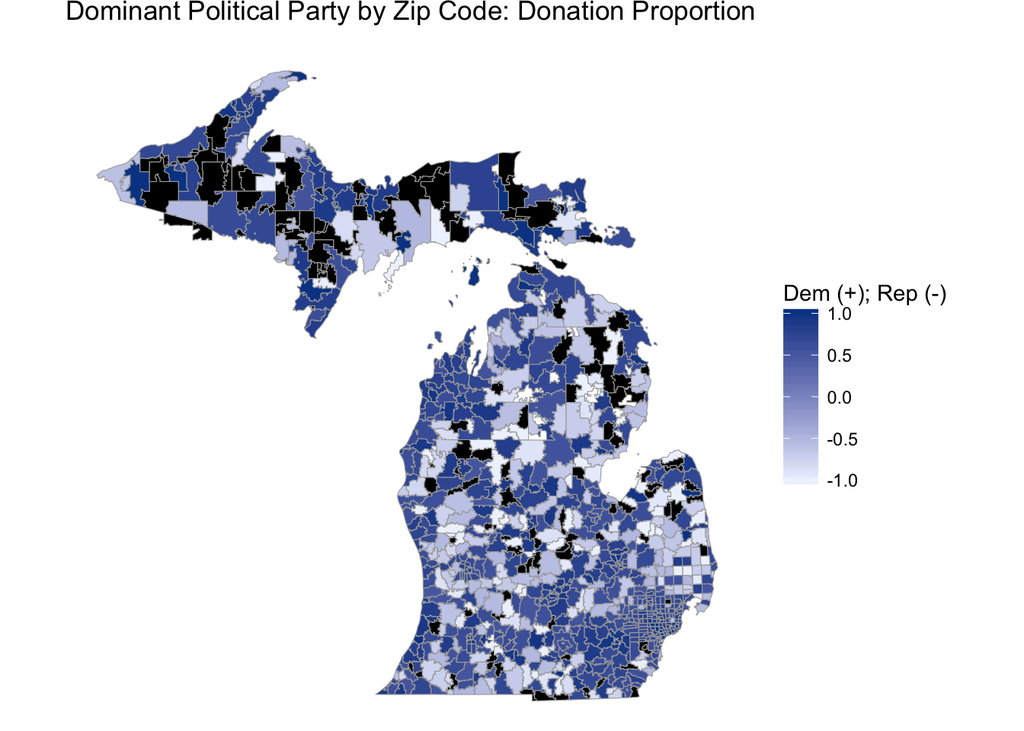

### Description Two

On the above map, the darker zip codes code as Democratic and the lighter ones as Republican. As you can see, the Metro Detroit area and a majority of the coastal zip codes are Democratic, while the Republican patches are spread out around the state and tend to be landlocked.

For the politcal party calculations, I select the dominant party (based on number of contributions) for each zip code and calculate the percentage of total contributions that party receives.

## Plot Three

### Support for Hillary vs. Trump over Time (segmented by gender)

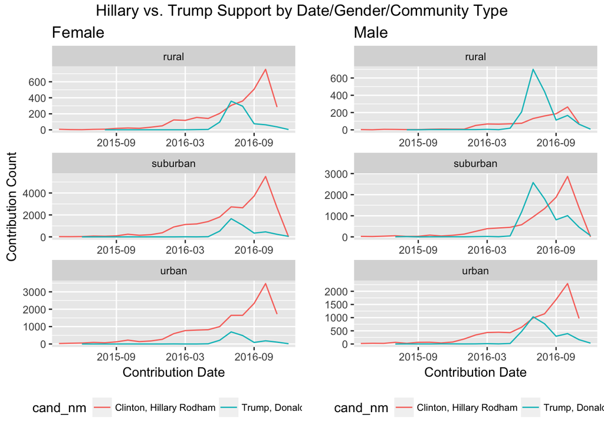

### Description Three

Finally, I investigate how support for Hillary vs. Trump differed by gender and community type as a function of time. In general female voters favored Hillary, while male voters favored Trump. In terms of community type, city dwellers were more likely to support Hillary while rural Michiganders supported Trump.

Rural women and urban men are particularly intriguing since they’re combinations of opposing political leanings demographics. They also have extremely similar contribution profiles. In general, they leaned toward supporting Hillary, but both had a moment in July (during convention season and the DNC email scandal) when they were more supportive of Trump.

# Reflection

### Features Examined

contribution

- amount
- date

candidate

- political party

contributor

- employer
- occupation
- gender

zip code

- population density
- community type
- unemployment rate
- political party leaning

### Takeaways

I learned so much through this exploration! One discovery that came up throughout my analysis was that Michigan residents donated more (based on number of contributions) to Democratic candidates, but made larger individual contributions to Republicans. Another discovery was that Democrats tend to be urban, female and located on the coasts, while Republicans tend to be rural, male and landlocked. A final takeway was how clearly you can see campaign events (like primaries, conventions and scandals) in the data.

#### Surprises

After the 2016 election, I heard so much about how women voted for Trump in droves, which supposedly won the election for him. What surprised me from this analysis is that although this may be true from a voter turnout level, it’s not what is reflected in the individual contributor data.

Other things that suprised me surrounded the campaign timeline and candidate support. Prior to this investigation, I didn’t realize what strong support Bernie enjoyed between the primaries and DNC, or what minimal support Trump had in comparison to other Republican candidates before the Republican Primary. Another timeframe surprise was that Michigan men actually made more total contributions to Hillary than Trump in the months leading up to the general election.

#### Struggles

The main struggle that I encountered during this project was learning the idiosyncrasies of R and ggplot. I also encountered several situations where numeric columns were encoded as factor data, which led to issues where I couldn’t plot correctly because the values weren’t recognized as continuous. I solved these factor problems by simply converting to numeric values.

#### Next Steps

As next steps, I would like to more closely examine how community type (rural, suburban, urban) affects contribution outcomes using race, income and voting statistics. Once these features are included, I would like to delve into individual cities and regions within Michigan to better understand campaign donation and voting tendencies.